# Moorea Coral Reef Productivity Analysis: Long-term Ecosystem Dynamics

## SEM Path Coefficients

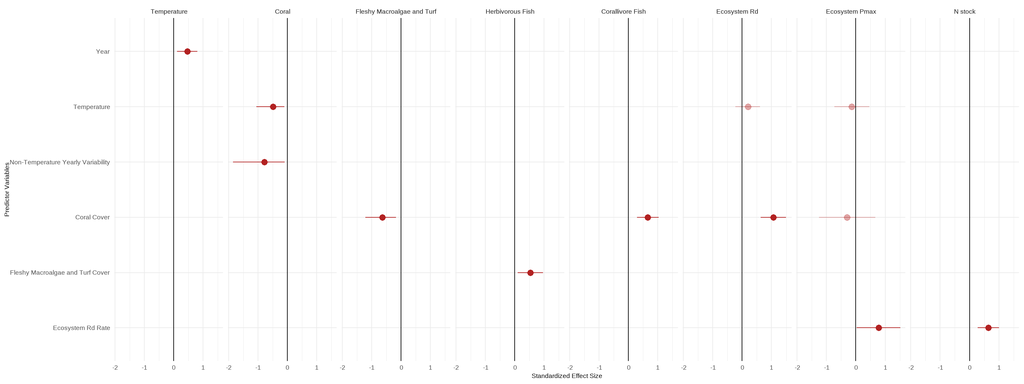

Figure 4: **Figure 4.** SEM path coefficient effect sizes.

```r
# Extract and format path coefficients
gp_edges <- as_tibble(fixef(brms_sem_full)) |>
  mutate(coef = rownames(fixef(brms_sem_full))) |>
  separate(col = coef, into = c("resp", "pred")) |>
  filter(pred != "Intercept") |>
  rename(est = Estimate, lo = `Q2.5`, hi = `Q97.5`) |>
  mutate(sig = if_else(sign(lo) == sign(hi), 1, 0.5)) |>
  mutate(resp = case_when(
    resp == "temperature" ~ "Temperature",
    resp == "logfleshy" ~ "Fleshy Macroalgae and Turf",
    resp == "logpmax" ~ "Ecosystem Pmax",
    resp == "logrd" ~ "Ecosystem Rd",
    resp == "herbs" ~ "Herbivorous Fish",
    resp == "Corallivore" ~ "Corallivore Fish",
    resp == "logcoral" ~ "Coral",
    resp == "Npercent" ~ "N stock"
  )) |>
  mutate(resp = factor(resp, c(
    "Temperature", "Coral", "Fleshy Macroalgae and Turf", "Herbivorous Fish",
    "Corallivore Fish", "Ecosystem Rd", "Ecosystem Pmax", "N stock"
  ))) |>
  mutate(pred = case_when(
    pred == "temperature" ~ "Temperature",
    pred == "mitemperature" ~ "Temperature",
    pred == "milogrd" ~ "Ecosystem Rd Rate",
    pred == "logcoral" ~ "Coral Cover",
    pred == "logfleshy" ~ "Fleshy Macroalgae and Turf Cover",
    pred == "Year" ~ "Year",
    pred == "yearresid" ~ "Non-Temperature Yearly Variability"
  )) |>
  mutate(pred = factor(pred, c(
    "Ecosystem Rd Rate", "Fleshy Macroalgae and Turf Cover",
    "Coral Cover", "Non-Temperature Yearly Variability",
    "Temperature", "Year"
  )))

gp_edges |>
  ggplot(aes(x = est, y = pred)) +
  geom_point(size = 3, color = "firebrick", aes(alpha = sig)) +
  geom_errorbarh(aes(xmin = lo, xmax = hi, alpha = sig), height = 0, color = "firebrick") +
  geom_vline(xintercept = 0) +
  scale_alpha(range = c(0.4, 1)) +
  labs(
    x = "Standardized Effect Size",
    y = "Predictor Variables"
  ) +
  theme_minimal() +
  facet_wrap(~resp, nrow = 1) +
  theme(
    text = element_text(size = 14),
    axis.text = element_text(size = 14),
    strip.text = element_text(size = 14),
    legend.position = "none"
  )

ggsave(here("Output", "fig4_sem_paths.pdf"), width = 16, height = 6)
```

## Temperature Effects: Direct vs Indirect

```
# A tibble: 6 × 5
  response                 median  lower  upper significant
  <fct>                     <dbl>  <dbl>  <dbl> <lgl>
1 Ecosystem Respiration    -0.481 -1.22  -0.098 TRUE
2 N Content                -0.298 -0.839 -0.047 TRUE
3 Corallivorous Fish       -0.295 -0.778 -0.049 TRUE
4 Ecosystem Pmax            0.121 -0.344  0.74  FALSE
5 Herbivorous Fish          0.139  0.001  0.501 TRUE
6 Fleshy & Turf Macroalgae  0.279  0.023  0.813 TRUE
```

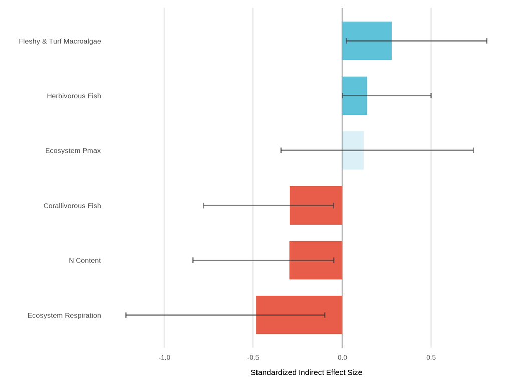

Figure 5: **Figure 5.** Indirect effects of temperature mediated through coral cover.

```r
# Extract only indirect effects and rank them
indirect_effects <- all_effects |>
  filter(effect_type == "Indirect") |>
  # Remove coral (no indirect effect)
  filter(response != "Coral Cover") |>
  arrange(median) |>
  mutate(
    response = fct_reorder(response, median),
    direction = if_else(median < 0, "Negative", "Positive")
  )
indirect_effects |>
  ggplot(aes(y = response, x = median, fill = direction, alpha = significant)) +
  geom_vline(xintercept = 0, linetype = "solid", color = "gray30", linewidth = 0.5) +
  geom_col(width = 0.7) +
  geom_errorbarh(
    aes(xmin = lower, xmax = upper),
    height = 0.1,
    linewidth = 0.8,
    color = "gray20",
    alpha = 0.6
  ) +
  scale_fill_manual(
    values = c("Negative" = "#E64B35", "Positive" = "#4DBBD5"),
    name = "Effect Direction"
  ) +
  scale_alpha_manual(
    values = c("TRUE" = 0.9, "FALSE" = 0.2),
    guide = "none"
  ) +
  labs(
    x = "Standardized Indirect Effect Size",
    y = ""
  ) +
  theme_minimal(base_size = 18) +
  theme(
    axis.text.y = element_text(size = 16, hjust = 1),
    axis.text.x = element_text(size = 15),
    axis.title.x = element_text(size = 17, margin = margin(t = 10)),
    legend.position = "none",
    legend.title = element_text(size = 16),
    legend.text = element_text(size = 15),
    panel.grid.major.y = element_blank(),
    panel.grid.minor = element_blank()
  )

ggsave(here("Output", "fig5_temp_indirect.pdf"), width = 8, height = 6)

# Print a ranked summary table of the indirect effects for quick inspection
indirect_effects |>
  select(response, median, lower, upper, significant) |>
  mutate(across(median:upper, ~round(.x, 3))) |>
  arrange(median)
```

## SEM Conditional Effects

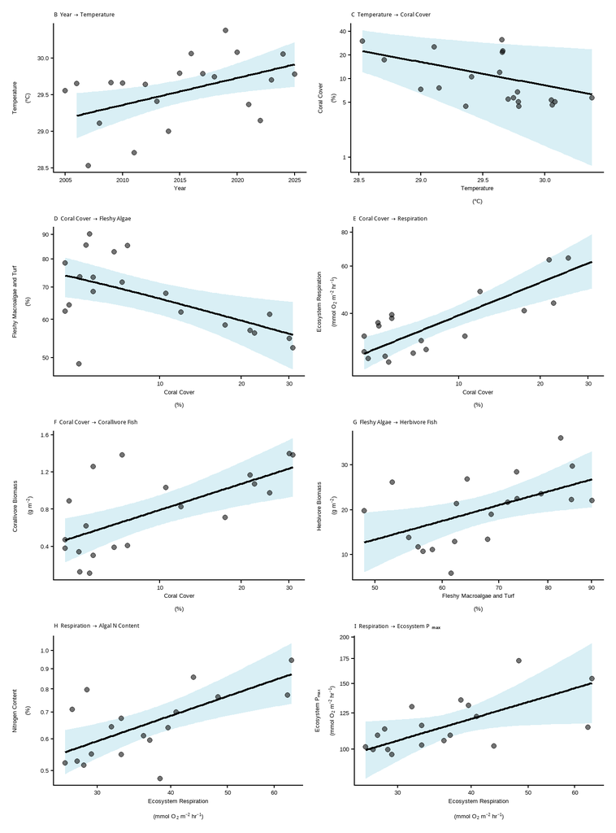

Figure 6: **Figure 6.** Conditional effects from the Bayesian SEM.

```r
# Unscaling parameters
yearresid_full <- resid(lm(Year ~ Max_temp, data = Year_Averages, na.action = na.exclude))

Yearmodelvalues <- Year_Averages |>
  mutate(
    log_coral = log(mean_coral),
    logfleshy = log(mean_fleshy),
    logrd     = log(Rd),
    logpmax   = log(Pmax),
    N_percent = log(N_percent),
    yearresid = yearresid_full
  ) |>
  select(
    Year, meancoral = mean_coral, meanfleshy = mean_fleshy,
    temperature = Max_temp,
    Npercent = N_percent,
    logrd, logpmax, logcoral = log_coral,
    logfleshy, Corallivore, herbs = Herbivores, yearresid
  ) |>
  drop_na(logcoral)

modelmean <- Yearmodelvalues |> summarise(across(everything(), \(x) mean(x, na.rm = TRUE)))
modelsd   <- Yearmodelvalues |> summarise(across(everything(), \(x) sd(x,   na.rm = TRUE)))

# ── Shared theme: 10 pt, exported at 183 × 247 mm ──────────────────────────
base_sz <- 10
rib_a   <- 0.25
rib_cl  <- "#67bed9"
ln_sz   <- 0.8
pt_sz   <- 1.8

theme_cond <- theme_classic(base_size = base_sz) +
  theme(
    plot.title   = element_text(size = base_sz, face = "bold"),
    axis.title   = element_text(size = base_sz),
    axis.text    = element_text(size = base_sz, color = "black"),
    axis.line    = element_line(linewidth = 0.4),
    axis.ticks   = element_line(linewidth = 0.4)
  )

# ── Row 1: Climate drivers ─────────────────────────────────────────────────

temp_year <- conditional_effects(brms_sem_full, resp = "temperature", effects = "Year")
ty_plot <- as_tibble(temp_year$temperature.temperature_Year) |>
  mutate(
    Year       = Year       * modelsd$Year        + modelmean$Year,
    estimate__ = estimate__ * modelsd$temperature + modelmean$temperature,
    lower__    = lower__    * modelsd$temperature + modelmean$temperature,
    upper__    = upper__    * modelsd$temperature + modelmean$temperature
  ) |>
  ggplot(aes(x = Year, y = estimate__)) +
  geom_ribbon(aes(ymin = lower__, ymax = upper__), alpha = rib_a, fill = rib_cl) +
  geom_line(linewidth = ln_sz) +
  geom_point(data = Year_Averages, aes(x = Year, y = Max_temp), size = pt_sz, alpha = 0.55) +
  labs(x = "Year", y = "Temperature\n(\u00b0C)", title = "B  Year \u2192 Temperature") +
  theme_cond

coral_temp <- conditional_effects(brms_sem_full, resp = "logcoral", effects = "temperature")
ct_plot <- as_tibble(coral_temp$logcoral.logcoral_temperature) |>
  mutate(
    temperature = temperature * modelsd$temperature + modelmean$temperature,
    estimate__  = exp(estimate__ * modelsd$logcoral + modelmean$logcoral),
    lower__     = exp(lower__    * modelsd$logcoral + modelmean$logcoral),
    upper__     = exp(upper__    * modelsd$logcoral + modelmean$logcoral)
  ) |>
  ggplot(aes(x = temperature, y = estimate__)) +
  geom_ribbon(aes(ymin = lower__, ymax = upper__), alpha = rib_a, fill = rib_cl) +
  geom_line(linewidth = ln_sz) +
  geom_point(data = Year_Averages, aes(x = Max_temp, y = exp(log_coral)), size = pt_sz, alpha = 0.55) +
  coord_transform(y = "log") +
  scale_y_continuous(breaks = c(1, 5, 10, 20, 40)) +
  labs(x = "Temperature\n(\u00b0C)", y = "Coral Cover\n(%)",
       title = "C  Temperature \u2192 Coral Cover") +
  theme_cond

# ── Row 2: Coral → benthos ─────────────────────────────────────────────────

fleshy_coral <- conditional_effects(brms_sem_full, resp = "logfleshy", effects = "logcoral")
fc_plot <- as_tibble(fleshy_coral$logfleshy.logfleshy_logcoral) |>
  mutate(
    logcoral   = exp(logcoral   * modelsd$logcoral  + modelmean$logcoral),
    estimate__ = exp(estimate__ * modelsd$logfleshy + modelmean$logfleshy),
    lower__    = exp(lower__    * modelsd$logfleshy + modelmean$logfleshy),
    upper__    = exp(upper__    * modelsd$logfleshy + modelmean$logfleshy)
  ) |>
  ggplot(aes(x = logcoral, y = estimate__)) +
  geom_ribbon(aes(ymin = lower__, ymax = upper__), alpha = rib_a, fill = rib_cl) +
  geom_line(linewidth = ln_sz) +
  geom_point(data = Year_Averages, aes(x = exp(log_coral), y = mean_fleshy), size = pt_sz, alpha = 0.55) +
  coord_transform(x = "log", y = "log") +
  labs(x = "Coral Cover\n(%)", y = "Fleshy Macroalgae and Turf \n(%)",
       title = "D  Coral Cover \u2192 Fleshy Algae") +
  theme_cond

rd_coral <- conditional_effects(brms_sem_full, resp = "logrd", effects = "logcoral")
rc_plot <- as_tibble(rd_coral$logrd.logrd_logcoral) |>
  mutate(
    logcoral   = exp(logcoral   * modelsd$logcoral + modelmean$logcoral),
    estimate__ = exp(estimate__ * modelsd$logrd    + modelmean$logrd),
    lower__    = exp(lower__    * modelsd$logrd    + modelmean$logrd),
    upper__    = exp(upper__    * modelsd$logrd    + modelmean$logrd)
  ) |>
  ggplot(aes(x = logcoral, y = estimate__)) +
  geom_ribbon(aes(ymin = lower__, ymax = upper__), alpha = rib_a, fill = rib_cl) +
  geom_line(linewidth = ln_sz) +
  geom_point(data = Year_Averages, aes(x = exp(log_coral), y = Rd), size = pt_sz, alpha = 0.55) +
  coord_transform(x = "log", y = "log") +
  labs(
    x = "Coral Cover\n(%)",
    y = expression(atop("Ecosystem Respiration", "(mmol O"[2]*" m"^-2*" hr"^-1*")")),
    title = "E  Coral Cover \u2192 Respiration"
  ) +
  theme_cond

# ── Row 3: Coral → fish ────────────────────────────────────────────────────

corallivore_coral <- conditional_effects(brms_sem_full, resp = "Corallivore", effects = "logcoral")
cc_plot <- as_tibble(corallivore_coral$Corallivore.Corallivore_logcoral) |>
  mutate(
    logcoral   = exp(logcoral   * modelsd$logcoral    + modelmean$logcoral),
    estimate__ = estimate__     * modelsd$Corallivore + modelmean$Corallivore,
    lower__    = lower__        * modelsd$Corallivore + modelmean$Corallivore,
    upper__    = upper__        * modelsd$Corallivore + modelmean$Corallivore
  ) |>
  ggplot(aes(x = logcoral, y = estimate__)) +
  geom_ribbon(aes(ymin = lower__, ymax = upper__), alpha = rib_a, fill = rib_cl) +
  geom_line(linewidth = ln_sz) +
  geom_point(data = Year_Averages, aes(x = exp(log_coral), y = Corallivore), size = pt_sz, alpha = 0.55) +
  coord_transform(x = "log") +
  labs(
    x = "Coral Cover\n(%)",
    y = expression(atop("Corallivore Biomass", "(g m"^-2*")")),
    title = "F  Coral Cover \u2192 Corallivore Fish"
  ) +
  theme_cond

herbs_fleshy <- conditional_effects(brms_sem_full, resp = "herbs", effects = "logfleshy")
hf_plot <- as_tibble(herbs_fleshy$herbs.herbs_logfleshy) |>
  mutate(
    logfleshy  = exp(logfleshy  * modelsd$logfleshy + modelmean$logfleshy),
    estimate__ = estimate__     * modelsd$herbs     + modelmean$herbs,
    lower__    = lower__        * modelsd$herbs     + modelmean$herbs,
    upper__    = upper__        * modelsd$herbs     + modelmean$herbs
  ) |>
  ggplot(aes(x = logfleshy, y = estimate__)) +
  geom_ribbon(aes(ymin = lower__, ymax = upper__), alpha = rib_a, fill = rib_cl) +
  geom_line(linewidth = ln_sz) +
  geom_point(data = Year_Averages, aes(x = mean_fleshy, y = Herbivores), size = pt_sz, alpha = 0.55) +
  coord_transform(x = "log") +
  labs(
    x = "Fleshy Macroalgae and Turf \n(%)",
    y = expression(atop("Herbivore Biomass", "(g m"^-2*")")),
    title = "G  Fleshy Algae \u2192 Herbivore Fish"
  ) +
  theme_cond

# ── Row 4: Metabolism → ecosystem function ─────────────────────────────────

N_Rd <- conditional_effects(brms_sem_full, resp = "Npercent", effects = "logrd")
nr_plot <- as_tibble(N_Rd$Npercent.Npercent_logrd) |>
  mutate(
    logrd      = exp(logrd      * modelsd$logrd    + modelmean$logrd),
    estimate__ = exp(estimate__ * modelsd$Npercent + modelmean$Npercent),
    lower__    = exp(lower__    * modelsd$Npercent + modelmean$Npercent),
    upper__    = exp(upper__    * modelsd$Npercent + modelmean$Npercent)
  ) |>
  ggplot(aes(x = logrd, y = estimate__)) +
  geom_ribbon(aes(ymin = lower__, ymax = upper__), alpha = rib_a, fill = rib_cl) +
  geom_line(linewidth = ln_sz) +
  geom_point(data = Year_Averages, aes(x = Rd, y = N_percent), size = pt_sz, alpha = 0.55) +
  coord_transform(x = "log", y = "log") +
  labs(
    x = expression(atop("Ecosystem Respiration", "(mmol O"[2]*" m"^-2*" hr"^-1*")")),
    y = "Nitrogen Content\n(%)",
    title = "H  Respiration \u2192 Algal N Content"
  ) +
  theme_cond

rd_pmax <- conditional_effects(brms_sem_full, resp = "logpmax", effects = "logrd")
rp_plot <- as_tibble(rd_pmax$logpmax.logpmax_logrd) |>
  mutate(
    logrd      = exp(logrd      * modelsd$logrd   + modelmean$logrd),
    estimate__ = exp(estimate__ * modelsd$logpmax + modelmean$logpmax),
    lower__    = exp(lower__    * modelsd$logpmax + modelmean$logpmax),
    upper__    = exp(upper__    * modelsd$logpmax + modelmean$logpmax)
  ) |>
  ggplot(aes(x = logrd, y = estimate__)) +
  geom_ribbon(aes(ymin = lower__, ymax = upper__), alpha = rib_a, fill = rib_cl) +
  geom_line(linewidth = ln_sz) +
  geom_point(data = Year_Averages, aes(x = Rd, y = Pmax), size = pt_sz, alpha = 0.55) +
  coord_transform(x = "log", y = "log") +
  labs(
    x = expression(atop("Ecosystem Respiration", "(mmol O"[2]*" m"^-2*" hr"^-1*")")),
    y = expression(atop("Ecosystem P"[max], "(mmol O"[2]*" m"^-2*" hr"^-1*")")),
    title = expression(bold("I  Respiration \u2192 Ecosystem P"[max]))
  ) +
  theme_cond

# ── Assemble 4 × 2 grid and export at 183 × 247 mm ─────────────────────────
fig_cond <- (ty_plot | ct_plot) /
            (fc_plot | rc_plot) /
            (cc_plot | hf_plot) /
            (nr_plot | rp_plot)

ggsave(
  here("Output", "fig6_sem_conditional.pdf"),
  plot   = fig_cond,
  width  = 183,
  height = 247,
  units  = "mm",
  device = cairo_pdf
)

fig_cond
```

## Ecosystem Projections

```r
# These are the upper truncation values on the z-log scale that correspond to
# 100% benthic cover. They were calculated from the observed data and hardcoded
# here so that projection code uses exactly the same ceiling as the SEM.
# Both values were verified to back-transform to exactly 100% cover.
z_ceil_coral  <- 3.39   # (log(100) - mean(log(coral%))) / sd(log(coral%))
z_ceil_fleshy <- 2.26   # (log(100) - mean(log(fleshy%))) / sd(log(fleshy%))
```

```r
#| label: full-sem-proj-data
#| echo: false
#| message: false
#| warning: false
# Compute full-SEM projection matrices — needed by the reduced SEM comparison plot.

# ── Projection years (standardised to SEM scale) ─────────────────────────────
proj_years <- 2005:2055
year_std   <- (proj_years - modelmean$Year) / modelsd$Year

# 3 000 thinned posterior draws
set.seed(7341)
post <- as_draws_df(brms_sem_full) |>
  as_tibble() |>
  slice_sample(n = 3000)

n <- nrow(post)
p <- length(proj_years)

# Helper: multiply each row of an (n × p) matrix by a length-n coefficient vector
rs <- function(coef, mat) sweep(mat, 1, coef, "*")
yr_mat <- matrix(rep(year_std, each = n), nrow = n)  # n × p

# ── Propagate causal chain through the full SEM ───────────────────────────────
# 1. Temperature (z-scored)
temp_mat <- rs(post$b_temperature_Year, yr_mat) + post$b_temperature_Intercept

# ── yearresid matrix: observed z-scaled values for hindcast (2005–2025),
#    0 (standardised mean) for forecast years (2026–2055). yearresid captures
#    year-specific temperature anomalies beyond the linear trend; setting it to 0
#    for forecast years assumes future deviations are unknown and average out.
obs_yr_actual   <- round(semdata2$Year * modelsd$Year + modelmean$Year)
yr_resid_lookup <- tibble(Year = obs_yr_actual, yr = semdata2$yearresid)
yr_resid_vec    <- sapply(proj_years, function(y) {
  row <- yr_resid_lookup |> filter(Year == y)
  if (nrow(row) == 1 && !is.na(row$yr)) row$yr else 0
})
yr_resid_mat <- matrix(rep(yr_resid_vec, each = n), nrow = n)

# 2. Coral cover (log-standardised; temperature + yearresid predictors)
coral_mat <- rs(post$b_logcoral_temperature, temp_mat)    +
             rs(post$b_logcoral_yearresid,   yr_resid_mat) +
             post$b_logcoral_Intercept

# 3. Ecosystem respiration (coral + direct temp via bsp for mi() imputed predictor)
rd_mat <- rs(post$b_logrd_logcoral,          coral_mat) +
          rs(post$bsp_logrd_mitemperature,   temp_mat)  +
          post$b_logrd_Intercept

# 4. Fleshy macroalgae (log-standardised; coral predictor)
fleshy_mat <- pmin(rs(post$b_logfleshy_logcoral, coral_mat) + post$b_logfleshy_Intercept,
                   z_ceil_fleshy)

# 5. Corallivore fish (z-scored; coral predictor)
cov_mat <- rs(post$b_Corallivore_logcoral, coral_mat) + post$b_Corallivore_Intercept

# 6. Herbivore fish (z-scored; fleshy algae predictor)
herb_mat <- rs(post$b_herbs_logfleshy, fleshy_mat) + post$b_herbs_Intercept

# 7. Ecosystem Pmax (log-standardised; rd + coral + temp, all via bsp/b)
pmax_mat <- rs(post$bsp_logpmax_milogrd,      rd_mat)    +
            rs(post$b_logpmax_logcoral,        coral_mat) +
            rs(post$bsp_logpmax_mitemperature, temp_mat)  +
            post$b_logpmax_Intercept

# 8. Algal N content (log-standardised; rd via bsp imputed)
n_mat <- rs(post$bsp_Npercent_milogrd, rd_mat) + post$b_Npercent_Intercept

# ── Back-transform to original units ─────────────────────────────────────────
bt_log <- function(mat, mu, sig) exp(mat * sig + mu)
bt_lin <- function(mat, mu, sig) mat * sig + mu

proj_list <- list(
  Temperature    = bt_lin(temp_mat,   modelmean$temperature, modelsd$temperature),
  `Coral Cover`  = bt_log(coral_mat,  modelmean$logcoral,    modelsd$logcoral),
  Respiration    = bt_log(rd_mat,     modelmean$logrd,       modelsd$logrd),
  `Fleshy Algae` = bt_log(fleshy_mat, modelmean$logfleshy,   modelsd$logfleshy),
  Pmax           = bt_log(pmax_mat,   modelmean$logpmax,     modelsd$logpmax),
  # N_percent is log-transformed in semdata2; use explicit log-scale params
  `N Content`    = bt_log(n_mat,
                          mean(log(Year_Averages$N_percent), na.rm = TRUE),
                          sd(log(Year_Averages$N_percent),   na.rm = TRUE))
)

# Derive P:R ratio directly from back-transformed Pmax and Rd matrices
proj_list[["P:R Ratio"]] <- proj_list$Pmax / proj_list$Respiration

# ── Summarise: posterior median + 50% + 95% CI per variable per year ─────────
proj_tbl <- imap_dfr(proj_list, function(mat, vname) {
  tibble(variable = vname,
         Year     = rep(proj_years, each = n),
         value    = as.vector(mat)) |>
    group_by(variable, Year) |>
    summarise(median = median(value, na.rm = TRUE),
              lo95   = quantile(value, 0.025, na.rm = TRUE), hi95 = quantile(value, 0.975, na.rm = TRUE),
              lo50   = quantile(value, 0.25,  na.rm = TRUE), hi50 = quantile(value, 0.75,  na.rm = TRUE),
              .groups = "drop")
})

# ── Observed data for overlay ─────────────────────────────────────────────────
obs_proj <- Year_Averages |>
  transmute(Year,
            Temperature    = Max_temp,
            `Coral Cover`  = mean_coral,
            Respiration    = Rd,
            `Fleshy Algae` = mean_fleshy,
            Pmax           = Pmax,
            `N Content`    = N_percent,
            `P:R Ratio`    = Pmax / Rd) |>
  pivot_longer(-Year, names_to = "variable", values_to = "observed")
```

## Reduced SEM: Parsimonious Model

Three of the twelve pathways in the full SEM had 95% credible intervals spanning zero — direct temperature effects on respiration, direct temperature effects on Pmax , and a direct coral effect on Pmax — indicating that these pathways are not reliably supported by the data. Retaining them in projection creates two problems: the positive temperature→Rd coefficient generates a spurious upward push on Rd when temperature is extrapolated beyond the fitted range, and the large uncertainty on the coral→Pmax and temperature→Pmax terms inflates Pmax credible intervals. A reduced 9-pathway SEM was therefore fitted with these three terms removed.

```r
# Reduced SEM: remove 3 non-significant pathways
bf_temp_r        <- bf(temperature | mi()             ~ 1 + Year)
bf_coraltemp_r   <- bf(logcoral    | trunc(ub = 3.39) ~ 1 + temperature + yearresid +
                         ar(time = Year, p = 1))
bf_logrd_r       <- bf(logrd       | mi()             ~ 1 + logcoral)
bf_logpmax_r     <- bf(logpmax     | mi()             ~ 1 + mi(logrd))
bf_fleshy_r      <- bf(logfleshy   | trunc(ub = 2.26) ~ logcoral)
bf_herbs_r       <- bf(herbs       | mi()             ~ 1 + logfleshy)
bf_corallivore_r <- bf(Corallivore | mi()             ~ 1 + logcoral)
bf_nutrients_r   <- bf(Npercent    | mi()             ~ 1 + mi(logrd))

brms_sem_reduced <- brm(
  bf_temp_r + bf_coraltemp_r + bf_logrd_r + bf_herbs_r + bf_corallivore_r +
    bf_nutrients_r + bf_fleshy_r + bf_logpmax_r + set_rescor(FALSE),
  data    = semdata2,
  chains  = 3, iter = 10000, warmup = 5000, seed = 11,
  sample_prior = "no",
  prior   = c(
    # b-class priors per response (logpmax and Npercent excluded: only mi() predictors
    # → class bsp, not b)
    set_prior("normal(0, 2)", class = "b", resp = "temperature"),
    set_prior("normal(0, 2)", class = "b", resp = "logcoral"),
    set_prior("normal(0, 2)", class = "b", resp = "logrd"),
    set_prior("normal(0, 2)", class = "b", resp = "herbs"),
    set_prior("normal(0, 2)", class = "b", resp = "Corallivore"),
    set_prior("normal(0, 2)", class = "b", resp = "logfleshy"),
    # Intercept priors for all responses
    set_prior("normal(0, 2)", class = "Intercept", resp = "temperature"),
    set_prior("normal(0, 2)", class = "Intercept", resp = "logcoral"),
    set_prior("normal(0, 2)", class = "Intercept", resp = "logrd"),
    set_prior("normal(0, 2)", class = "Intercept", resp = "logpmax"),
    set_prior("normal(0, 2)", class = "Intercept", resp = "herbs"),
    set_prior("normal(0, 2)", class = "Intercept", resp = "Corallivore"),
    set_prior("normal(0, 2)", class = "Intercept", resp = "logfleshy"),
    set_prior("normal(0, 2)", class = "Intercept", resp = "Npercent"),
    # Response-specific essential priors
    set_prior("normal(0, 0.25)", resp = "temperature", class = "sigma", lb = 0),
    set_prior("normal(0, 0.5)",  class = "ar",  resp = "logcoral")
  ),
  control = list(adapt_delta = 0.99, max_treedepth = 15),
  family  = gaussian(),
  silent = 2, refresh = 0
)
```

```r
summary(brms_sem_reduced)
```

```
 Family: MV(gaussian, gaussian, gaussian, gaussian, gaussian, gaussian, gaussian, gaussian)
  Links: mu = identity; sigma = identity
         mu = identity; sigma = identity
         mu = identity; sigma = identity
         mu = identity; sigma = identity
         mu = identity; sigma = identity
         mu = identity; sigma = identity
         mu = identity; sigma = identity
         mu = identity; sigma = identity
Formula: temperature | mi() ~ 1 + Year
         logcoral | trunc(ub = 3.39) ~ 1 + temperature + yearresid + ar(time = Year, p = 1)
         logrd | mi() ~ 1 + logcoral
         herbs | mi() ~ 1 + logfleshy
         Corallivore | mi() ~ 1 + logcoral
         Npercent | mi() ~ 1 + mi(logrd)
         logfleshy | trunc(ub = 2.26) ~ logcoral
         logpmax | mi() ~ 1 + mi(logrd)
   Data: semdata2 (Number of observations: 20)
  Draws: 3 chains, each with iter = 10000; warmup = 5000; thin = 1;
         total post-warmup draws = 15000

Correlation Structures:
               Estimate Est.Error l-95% CI u-95% CI Rhat Bulk_ESS Tail_ESS
ar_logcoral[1]     0.90      0.16     0.56     1.18 1.00     4359     6901

Regression Coefficients:
                      Estimate Est.Error l-95% CI u-95% CI Rhat Bulk_ESS
temperature_Intercept     0.00      0.17    -0.34     0.34 1.00    16876
logcoral_Intercept        0.20      0.76    -1.73     1.58 1.00     3339
logrd_Intercept           0.20      0.16    -0.14     0.52 1.00    11845
herbs_Intercept           0.00      0.21    -0.42     0.42 1.00    15630
Corallivore_Intercept    -0.00      0.19    -0.37     0.38 1.00    15965
Npercent_Intercept       -0.07      0.19    -0.44     0.31 1.00    15361
logfleshy_Intercept       0.11      0.32    -0.36     0.84 1.00     6362
logpmax_Intercept         0.00      0.21    -0.41     0.41 1.00    14576
temperature_Year          0.46      0.18     0.12     0.80 1.00    14965
logcoral_temperature     -0.49      0.23    -1.07    -0.10 1.00     3517
logcoral_yearresid       -0.78      0.41    -1.84    -0.10 1.00     3346
logrd_logcoral            0.95      0.19     0.58     1.34 1.00    10106
herbs_logfleshy           0.54      0.21     0.11     0.96 1.00    15310
```

[output cut: 22 more lines]

```

Further Distributional Parameters:
                  Estimate Est.Error l-95% CI u-95% CI Rhat Bulk_ESS Tail_ESS
sigma_temperature     0.77      0.09     0.61     0.97 1.00    16833    11297
sigma_logcoral        0.36      0.07     0.25     0.52 1.00    13557     9631
sigma_logrd           0.69      0.13     0.49     1.00 1.00    12544    10074
sigma_herbs           0.93      0.17     0.67     1.31 1.00    14671     9966
sigma_Corallivore     0.82      0.15     0.59     1.17 1.00    15209    10023
sigma_Npercent        0.79      0.15     0.56     1.14 1.00    12310     9509
sigma_logfleshy       1.00      0.28     0.66     1.73 1.00     6449     3402
sigma_logpmax         0.88      0.17     0.62     1.28 1.00    12355     9883

Draws were sampled using sampling(NUTS). For each parameter, Bulk_ESS
and Tail_ESS are effective sample size measures, and Rhat is the potential
scale reduction factor on split chains (at convergence, Rhat = 1).
```

```r
# Manual R² for mi()-imputed responses
for (resp in c("logrd", "logpmax")) {
  fit_f <- fitted(brms_sem_full,    resp = resp)[, "Estimate"]
  fit_r <- fitted(brms_sem_reduced, resp = resp)[, "Estimate"]
  obs_v <- semdata2[[resp]]
  ok    <- !is.na(obs_v)
  cat(sprintf("%-10s  Full R²: %.3f   Reduced R²: %.3f\n", resp,
              cor(fit_f[ok], obs_v[ok])^2, cor(fit_r[ok], obs_v[ok])^2))
}
```

```
logrd       Full R²: 0.659   Reduced R²: 0.620
logpmax     Full R²: 0.400   Reduced R²: 0.375
```

```r
set.seed(6214)
post_r <- as_draws_df(brms_sem_reduced) |> as_tibble() |> slice_sample(n = 3000)
n_r    <- nrow(post_r)

# yearresid matrix: observed for 2005-2025, zero for 2026-2055
yr_resid_vec_r <- sapply(proj_years, function(y) {
  row <- yr_resid_lookup |> filter(Year == y)
  if (nrow(row) == 1 && !is.na(row$yr)) row$yr else 0
})
yr_resid_mat_r <- matrix(rep(yr_resid_vec_r, each = n_r), nrow = n_r)
yr_mat_r       <- matrix(rep(year_std, each = n_r), nrow = n_r)

# ── Propagate reduced SEM causal chain ────────────────────────────────────────
temp_mat_r   <- rs(post_r$b_temperature_Year,     yr_mat_r)   + post_r$b_temperature_Intercept
coral_mat_r  <- rs(post_r$b_logcoral_temperature, temp_mat_r) +
                rs(post_r$b_logcoral_yearresid,   yr_resid_mat_r) +
                post_r$b_logcoral_Intercept
rd_mat_r     <- rs(post_r$b_logrd_logcoral, coral_mat_r)      + post_r$b_logrd_Intercept
fleshy_mat_r <- pmin(rs(post_r$b_logfleshy_logcoral, coral_mat_r) + post_r$b_logfleshy_Intercept,
                     z_ceil_fleshy)
cov_mat_r    <- rs(post_r$b_Corallivore_logcoral, coral_mat_r)+ post_r$b_Corallivore_Intercept
herb_mat_r   <- rs(post_r$b_herbs_logfleshy, fleshy_mat_r)    + post_r$b_herbs_Intercept
pmax_mat_r   <- rs(post_r$bsp_logpmax_milogrd, rd_mat_r)      + post_r$b_logpmax_Intercept
n_mat_r      <- rs(post_r$bsp_Npercent_milogrd, rd_mat_r)     + post_r$b_Npercent_Intercept

proj_list_r <- list(
  Temperature    = bt_lin(temp_mat_r,   modelmean$temperature, modelsd$temperature),
  `Coral Cover`  = bt_log(coral_mat_r,  modelmean$logcoral,    modelsd$logcoral),
  Respiration    = bt_log(rd_mat_r,     modelmean$logrd,       modelsd$logrd),
  `Fleshy Algae` = bt_log(fleshy_mat_r, modelmean$logfleshy,   modelsd$logfleshy),
  Pmax           = bt_log(pmax_mat_r,   modelmean$logpmax,     modelsd$logpmax),
  `N Content`    = bt_log(n_mat_r,
                          mean(log(Year_Averages$N_percent), na.rm = TRUE),
                          sd(log(Year_Averages$N_percent),   na.rm = TRUE))
)
proj_list_r[["P:R Ratio"]] <- proj_list_r$Pmax / proj_list_r$Respiration

proj_tbl_r <- imap_dfr(proj_list_r, function(mat, vname) {
  tibble(variable = vname, Year = rep(proj_years, each = n_r), value = as.vector(mat)) |>
    group_by(variable, Year) |>
    summarise(median = median(value, na.rm = TRUE),
              lo95 = quantile(value, .025, na.rm = TRUE), hi95 = quantile(value, .975, na.rm = TRUE),
              lo50 = quantile(value, .25,  na.rm = TRUE), hi50 = quantile(value, .75,  na.rm = TRUE),
              .groups = "drop")
})

# ── Counterfactual: temperature stabilised at 2025 ────────────────────────────
# temp_2025_std: z-standardised 2025 annual maximum temperature
# = (observed 2025 max temp - SEM temperature mean) / SEM temperature SD
# Use last non-NA Max_temp as the counterfactual (2025 is NA)
temp_2025_val <- Year_Averages |>
  filter(!is.na(Max_temp)) |>
  slice_max(Year, n = 1) |>
  pull(Max_temp)
temp_2025_std <- (temp_2025_val - modelmean$temperature) / modelsd$temperature
temp_mat_r_cf <- temp_mat_r
temp_mat_r_cf[, which(proj_years > 2025)] <- temp_2025_std

coral_mat_r_cf  <- rs(post_r$b_logcoral_temperature, temp_mat_r_cf)   +
                   rs(post_r$b_logcoral_yearresid,   yr_resid_mat_r)  +
                   post_r$b_logcoral_Intercept
rd_mat_r_cf     <- rs(post_r$b_logrd_logcoral, coral_mat_r_cf)        + post_r$b_logrd_Intercept
fleshy_mat_r_cf <- pmin(rs(post_r$b_logfleshy_logcoral, coral_mat_r_cf) + post_r$b_logfleshy_Intercept,
                        z_ceil_fleshy)
pmax_mat_r_cf   <- rs(post_r$bsp_logpmax_milogrd, rd_mat_r_cf)        + post_r$b_logpmax_Intercept
n_mat_r_cf      <- rs(post_r$bsp_Npercent_milogrd, rd_mat_r_cf)       + post_r$b_Npercent_Intercept

proj_tbl_r_cf <- imap_dfr(
  list(Temperature    = bt_lin(temp_mat_r_cf,   modelmean$temperature, modelsd$temperature),
       `Coral Cover`  = bt_log(coral_mat_r_cf,  modelmean$logcoral,    modelsd$logcoral),
       Respiration    = bt_log(rd_mat_r_cf,     modelmean$logrd,       modelsd$logrd),
       `Fleshy Algae` = bt_log(fleshy_mat_r_cf, modelmean$logfleshy,   modelsd$logfleshy),
       Pmax           = bt_log(pmax_mat_r_cf,   modelmean$logpmax,     modelsd$logpmax),
       `N Content`    = bt_log(n_mat_r_cf,
                               mean(log(Year_Averages$N_percent), na.rm = TRUE),
                               sd(log(Year_Averages$N_percent),   na.rm = TRUE))),
  function(mat, vname) {
    tibble(variable = vname, Year = rep(proj_years, each = n_r), value = as.vector(mat)) |>
      group_by(variable, Year) |>
      summarise(median = median(value, na.rm = TRUE),
                lo95 = quantile(value, .025, na.rm = TRUE), hi95 = quantile(value, .975, na.rm = TRUE),
                lo50 = quantile(value, .25,  na.rm = TRUE), hi50 = quantile(value, .75,  na.rm = TRUE),
                .groups = "drop")
  })
```

## Copernicus CDS CMIP6 SST Projections to 2100

```r
# ── Run once to store your CDS Personal Access Token securely ─────────────────
# 1. Log in at https://cds.climate.copernicus.eu/
# 2. Go to Profile (top-right) → Personal Access Tokens → copy your token
# 3. Paste it below and run this chunk once — it will not need to be run again.
wf_set_key(key = "YOUR-PERSONAL-ACCESS-TOKEN")
```

[output not shown]

[output cut: 129 more lines]

```r
# ── Propagate each SSP scenario through the reduced SEM ──────────────────────
# Approach: two uncertainty sources are kept separate.
#
#   Temperature panel  — shows the raw CMIP6 inter-model spread (p10/p90 of
#     the 10 bias-corrected models). This ribbon is NOT derived from the SEM.
#
#   Ecological panels  — driven by a single, deterministic ensemble-median
#     temperature trajectory per scenario. All 3,000 SEM posterior draws use
#     identical temperatures, so the ribbon reflects SEM path-coefficient
#     uncertainty only.
#


# ── Map scenario codes to experiment names used in ann_tos_bc ────────────────
ssp_experiment <- c(ssp126 = "ssp1_2_6", ssp245 = "ssp2_4_5", ssp585 = "ssp5_8_5")

# Build a bias-corrected model × year temperature matrix for a given scenario
get_model_temp_matrix <- function(scenario_name) {
  exp_name <- ssp_experiment[[scenario_name]]

  temps <- bind_rows(
    ann_tos_bc |> filter(experiment == "historical", year %in% 2005:2014),
    ann_tos_bc |> filter(experiment == exp_name,     year %in% 2015:2100)
  ) |>
    select(model, year, ann_max_bc)

  # Retain only models with a complete, non-missing 96-year series
  complete_models <- temps |>
    group_by(model) |>
    summarise(n = n(), ok = all(!is.na(ann_max_bc)), .groups = "drop") |>
    filter(n == 96L, ok) |>
    pull(model)

  temps |>
    filter(model %in% complete_models) |>
    arrange(model, year) |>
    pivot_wider(names_from = year, values_from = ann_max_bc) |>
    select(-model) |>
    as.matrix()                          # n_complete_models × 96
}

# ── CMIP6 ensemble temperature summary (for Temperature panel display) ────────
# Returns median, p10, and p90 across models for each scenario/year.
get_temp_ensemble_summary <- function(scenario_name) {
  temp_raw <- get_model_temp_matrix(scenario_name)   # n_models × 96 (2005:2100)

  # Historical (2005–2025): observed MCR temperatures, zero ribbon — mirrors the
  # two-period approach used for ecological variables so all panels are consistent.
  hist_rows <- Year_Averages |>
    filter(Year %in% 2005:2025) |>
    arrange(Year) |>
    transmute(
      scenario = scenario_name,
      variable = "Temperature",
      year     = Year,
      median   = Max_temp,
      lo95     = Max_temp, hi95 = Max_temp,
      lo50     = Max_temp, hi50 = Max_temp
    )

  # Projection (2026–2100): CMIP6 ensemble median + p10/p90 inter-model spread
  proj_rows <- tibble(
    scenario = scenario_name,
    variable = "Temperature",
    year     = 2026:2100,
    median   = apply(temp_raw[, 22:96, drop = FALSE], 2, median),
    lo95     = apply(temp_raw[, 22:96, drop = FALSE], 2, quantile, 0.10),
    hi95     = apply(temp_raw[, 22:96, drop = FALSE], 2, quantile, 0.90),
    lo50     = apply(temp_raw[, 22:96, drop = FALSE], 2, quantile, 0.25),
    hi50     = apply(temp_raw[, 22:96, drop = FALSE], 2, quantile, 0.75)
  )

  bind_rows(hist_rows, proj_rows)
}

propagate_wb_ssp <- function(scenario_name) {

  n_pct_log_mean <- mean(log(Year_Averages$N_percent), na.rm = TRUE)
  n_pct_log_sd   <- sd(log(Year_Averages$N_percent),   na.rm = TRUE)

  # ── CMIP6 ensemble-median temperature trajectory ──────────────────────────
  temp_raw     <- get_model_temp_matrix(scenario_name)
  temp_med_raw <- apply(temp_raw, 2, median)               # length 96 (2005:2100)
  temp_z_cmip6 <- (temp_med_raw - modelmean$temperature) / modelsd$temperature

  cmip6_z_2025 <- temp_z_cmip6[21]                         # index 21 = year 2025
  tm_proj      <- matrix(rep(temp_z_cmip6[22:96], each = n_r), nrow = n_r)  # n_r × 75

  # ── yearresid: held constant at its 2025 observed value ──────────────────
  # The yearresid captures secular (non-temperature) trends up to 2025. For
  # the projection period we hold it constant
  yr_2025 <- {
    row <- yr_resid_lookup |> filter(Year == 2025L)
    if (nrow(row) == 1L && !is.na(row$yr)) row$yr else 0
  }
  yr_rv_proj <- rep(yr_2025, 75)   # constant at 2025 level throughout projection
  yrm_proj   <- matrix(rep(yr_rv_proj, each = n_r), nrow = n_r)

  # ── SEM baseline at 2025 (CMIP6 T_2025 + observed yearresid_2025) ────────
  cm_base  <- pmin(post_r$b_logcoral_temperature * cmip6_z_2025 +
                   post_r$b_logcoral_yearresid   * yr_2025 +
                   post_r$b_logcoral_Intercept, z_ceil_coral)          # n_r
  rm_base  <- post_r$b_logrd_logcoral          * cm_base + post_r$b_logrd_Intercept
  fm_base  <- pmin(post_r$b_logfleshy_logcoral * cm_base +
                   post_r$b_logfleshy_Intercept, z_ceil_fleshy)
  pm_base  <- post_r$bsp_logpmax_milogrd  * rm_base + post_r$b_logpmax_Intercept
  nm_base  <- post_r$bsp_Npercent_milogrd * rm_base + post_r$b_Npercent_Intercept

  # ── SEM projection at 2026–2100 ───────────────────────────────────────────
  cm_proj  <- pmin(rs(post_r$b_logcoral_temperature, tm_proj) +
                   rs(post_r$b_logcoral_yearresid,   yrm_proj) +
                   post_r$b_logcoral_Intercept, z_ceil_coral)
  rm_proj  <- rs(post_r$b_logrd_logcoral,          cm_proj) + post_r$b_logrd_Intercept
  fm_proj  <- pmin(rs(post_r$b_logfleshy_logcoral, cm_proj) +
                   post_r$b_logfleshy_Intercept, z_ceil_fleshy)
  pm_proj  <- rs(post_r$bsp_logpmax_milogrd,  rm_proj) + post_r$b_logpmax_Intercept
  nm_proj  <- rs(post_r$bsp_Npercent_milogrd, rm_proj) + post_r$b_Npercent_Intercept

  # ── Observed z-scores at 2025 (anchor points) ────────────────────────────
  obs25 <- Year_Averages |> filter(Year == 2025)
  obs_cm_z <- (log(obs25$mean_coral)  - modelmean$logcoral)  / modelsd$logcoral
  obs_rm_z <- (log(obs25$Rd)          - modelmean$logrd)     / modelsd$logrd
  obs_fm_z <- (log(obs25$mean_fleshy) - modelmean$logfleshy) / modelsd$logfleshy
  obs_pm_z <- (log(obs25$Pmax)        - modelmean$logpmax)   / modelsd$logpmax
  # N_percent: use last non-NA year if 2025 is missing
  n_anchor <- if (!is.na(obs25$N_percent)) obs25$N_percent else {
    Year_Averages |> filter(!is.na(N_percent)) |> slice_max(Year, n = 1) |> pull(N_percent)
  }
  obs_nm_z <- (log(n_anchor) - n_pct_log_mean) / n_pct_log_sd

  # ── Delta-anchored projection matrices ───────────────────────────────────
  # anchored[draw, year] = obs_z_2025 + (proj[draw, year] - base[draw])
  cm_anch <- pmin(sweep(cm_proj, 1, cm_base, "-") + obs_cm_z, z_ceil_coral)
  rm_anch <- sweep(rm_proj, 1, rm_base, "-") + obs_rm_z
  fm_anch <- pmin(sweep(fm_proj, 1, fm_base, "-") + obs_fm_z, z_ceil_fleshy)
  pm_anch <- sweep(pm_proj, 1, pm_base, "-") + obs_pm_z
  nm_anch <- sweep(nm_proj, 1, nm_base, "-") + obs_nm_z

  proj_rows <- imap_dfr(
    list(`Coral Cover`  = bt_log(cm_anch, modelmean$logcoral,  modelsd$logcoral),
         Respiration    = bt_log(rm_anch, modelmean$logrd,     modelsd$logrd),
         `Fleshy Algae` = bt_log(fm_anch, modelmean$logfleshy, modelsd$logfleshy),
         Pmax           = bt_log(pm_anch, modelmean$logpmax,   modelsd$logpmax),
         `N Content`    = bt_log(nm_anch, n_pct_log_mean,      n_pct_log_sd)),
    function(mat, vname) {
      tibble(scenario = scenario_name, variable = vname,
             year = rep(2026:2100, each = n_r), value = as.vector(mat)) |>
        group_by(scenario, variable, year) |>
        summarise(median = median(value, na.rm = TRUE),
                  lo95   = quantile(value, .025, na.rm = TRUE),
                  hi95   = quantile(value, .975, na.rm = TRUE),
                  lo50   = quantile(value, .25,  na.rm = TRUE),
                  hi50   = quantile(value, .75,  na.rm = TRUE),
                  .groups = "drop")
    })

  # ── Historical period: observed values directly, zero ribbon ─────────────
  hist_rows <- Year_Averages |>
    filter(Year %in% 2005:2025) |>
    arrange(Year) |>
    transmute(scenario = scenario_name, year = Year,
              `Coral Cover` = mean_coral, Respiration = Rd,
              `Fleshy Algae` = mean_fleshy, Pmax = Pmax, `N Content` = N_percent) |>
    pivot_longer(cols = -c(scenario, year), names_to = "variable", values_to = "median") |>
    mutate(lo95 = median, hi95 = median, lo50 = median, hi50 = median)

  bind_rows(hist_rows, proj_rows)
}

wb_proj_eco <- bind_rows(lapply(c("ssp126", "ssp245", "ssp585"), propagate_wb_ssp))

# Temperature rows: ensemble p10/p90 ribbon (not SEM-derived)
wb_temp_tbl <- bind_rows(lapply(c("ssp126", "ssp245", "ssp585"), get_temp_ensemble_summary))

# Combined table used by plotting and summary table
wb_proj_tbl <- bind_rows(wb_temp_tbl, wb_proj_eco)

# ── Tidy for plotting ─────────────────────────────────────────────────────────
wb_ssp_labels  <- c(ssp126 = "SSP1-2.6", ssp245 = "SSP2-4.5", ssp585 = "SSP5-8.5")
wb_ssp_colours <- c(ssp126 = "#2196F3",  ssp245 = "#FF9800",   ssp585 = "#E53935")
wb_var_order   <- c("Temperature","Coral Cover","Respiration",
                    "Fleshy Algae","Pmax","N Content")
wb_var_units   <- c(Temperature    = "\u00b0C",
                    `Coral Cover`  = "% cover",
                    Respiration    = "mmol O\u2082 m\u207b\u00b2 hr\u207b\u00b9",
                    `Fleshy Algae` = "% cover",
                    Pmax           = "mmol O\u2082 m\u207b\u00b2 hr\u207b\u00b9",
                    `N Content`    = "% N")

wb_plot_tbl <- wb_proj_tbl |>
  mutate(variable       = factor(variable, levels = wb_var_order),
         scenario_label = wb_ssp_labels[scenario])
```

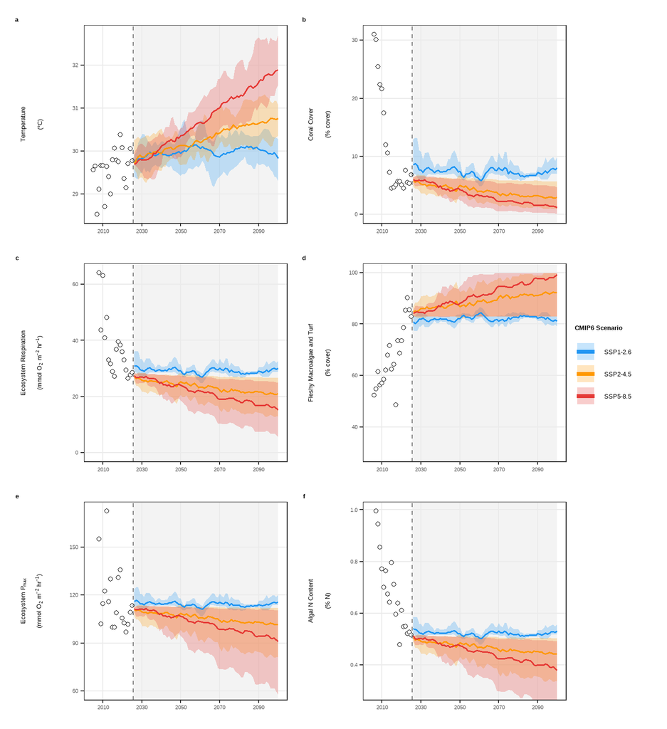

Figure 7: **Figure 7.** Ecosystem projections under CMIP6 SSP emissions scenarios (2005–2100).

```r
wb_y_limits <- list(
  Temperature    = NULL,
  `Coral Cover`  = c(0, NA),
  Respiration    = c(0, NA),
  `Fleshy Algae` = c(30, 100),
  Pmax           = c(60, NA),
  `N Content`    = c(0.3, NA)
)

# Y-axis labels: variable name + (units) on new line for ≥10 pt readability
# Use expression(atop()) for labels with superscripts/subscripts — plain Unicode
# characters for those (e.g. ⁻², O₂) are not reliably covered by PDF fonts.
wb_var_labels <- list(
  Temperature    = "Temperature\n(\u00b0C)",
  `Coral Cover`  = "Coral Cover\n(% cover)",
  Respiration    = expression(atop("Ecosystem Respiration", "(mmol O"[2]*" m"^-2*" hr"^-1*")")),
  `Fleshy Algae` = "Fleshy Macroalgae and Turf\n(% cover)",
  Pmax           = expression(atop("Ecosystem P"[max], "(mmol O"[2]*" m"^-2*" hr"^-1*")")),
  `N Content`    = "Algal N Content\n(% N)"
)

# Smooth trajectories for cleaner visualisation (projection period only):
#   Temperature  → median smoothed k=11; ribbon (inter-model p10/p90) smoothed k=5.
#   Ecological   → both median and ribbons smoothed k=5.
# Historical period (2005–2025) is never smoothed; observed values are unchanged.
wb_plot_tbl_smooth <- wb_plot_tbl |>
  dplyr::group_by(variable, scenario) |>
  dplyr::arrange(year) |>
  dplyr::mutate(
    is_temp = as.character(variable) == "Temperature",
    k       = dplyr::if_else(is_temp, 11L, 5L),
    in_proj = year > 2025,
    median_s = dplyr::if_else(
      in_proj,
      zoo::rollapply(median, width = k[1], FUN = mean, align = "center",
                     partial = TRUE, fill = NA, na.rm = TRUE),
      median
    ),
    lo95_s = dplyr::if_else(
      in_proj,
      zoo::rollapply(lo95, width = 5L, FUN = mean, align = "center",
                     partial = TRUE, fill = NA, na.rm = TRUE),
      lo95
    ),
    hi95_s = dplyr::if_else(
      in_proj,
      zoo::rollapply(hi95, width = 5L, FUN = mean, align = "center",
                     partial = TRUE, fill = NA, na.rm = TRUE),
      hi95
    )
  ) |>
  dplyr::ungroup()

make_wb_panel <- function(vname) {
  d_proj <- wb_plot_tbl_smooth |> filter(variable == vname, year > 2025)
  obs_v  <- Year_Averages |>
    select(year = Year,
           Temperature    = Max_temp,
           `Coral Cover`  = mean_coral,
           Respiration    = Rd,
           `Fleshy Algae` = mean_fleshy,
           Pmax           = Pmax,
           `N Content`    = N_percent) |>
    pivot_longer(-year, names_to = "variable", values_to = "obs") |>
    filter(variable == vname)
  ylim <- wb_y_limits[[vname]]
  ylab <- wb_var_labels[[vname]]

  # Ribbon and lines drawn only for projection period (2026–2100);
  # hindcast (2005–2025) shows raw observed points only.
  p <- ggplot(mapping = aes(colour = scenario, fill = scenario)) +
    annotate("rect", xmin = 2025.5, xmax = 2100, ymin = -Inf, ymax = Inf,
             fill = "grey92", alpha = .6) +
    geom_ribbon(data = d_proj, aes(x = year, ymin = lo95_s, ymax = hi95_s),
                alpha = 0.25, colour = NA) +
    geom_line(data = d_proj, aes(x = year, y = median_s), linewidth = 0.7) +
    geom_point(data = obs_v, aes(x = year, y = obs),
               colour = "black", size = 1.5, shape = 21, fill = "white",
               inherit.aes = FALSE) +
    geom_vline(xintercept = 2025.5, linetype = "dashed",
               colour = "grey50", linewidth = .4) +
    scale_colour_manual(values = wb_ssp_colours, labels = wb_ssp_labels, name = "Scenario") +
    scale_fill_manual(  values = wb_ssp_colours, labels = wb_ssp_labels, name = "Scenario") +
    scale_x_continuous(breaks = seq(2010, 2100, 20)) +
    labs(x = NULL, y = ylab) +
    theme_bw(base_size = 10) +
    theme(
      legend.position  = "none",
      plot.title       = element_blank(),
      panel.grid.minor = element_blank(),
      axis.title.y     = element_text(size = 10, lineheight = 1.1)
    )
  if (!is.null(ylim)) p <- p + coord_cartesian(ylim = ylim)
  p
}

wb_panels <- lapply(wb_var_order, make_wb_panel)

wb_legend_plot <- ggplot(
  wb_plot_tbl_smooth |> filter(variable == "Temperature"),
  aes(x = year, y = median_s, colour = scenario, fill = scenario)) +
  geom_ribbon(aes(ymin = lo95_s, ymax = hi95_s), alpha = .25, colour = NA) +
  geom_line(linewidth = .9) +
  scale_colour_manual(values = wb_ssp_colours, labels = wb_ssp_labels,
                      name = "CMIP6 Scenario") +
  scale_fill_manual(  values = wb_ssp_colours, labels = wb_ssp_labels,
                      name = "CMIP6 Scenario") +
  guides(colour = guide_legend(override.aes = list(linewidth = 1.5))) +
  theme_void() +
  theme(legend.position  = "right", legend.direction = "vertical",
        legend.title = element_text(size = 10, face = "bold"),
        legend.text  = element_text(size = 10))
wb_leg <- cowplot::get_legend(wb_legend_plot)

wb_main <- (wrap_plots(wb_panels, ncol = 2) & theme(legend.position = "none")) +
  plot_annotation(tag_levels = "a") &
  theme(plot.tag = element_text(size = 10, face = "bold"))
wb_fig7  <- cowplot::plot_grid(wb_main, wb_leg, ncol = 2, rel_widths = c(1, 0.15))

# Export at 183 × 200 mm ; base_size = 10 → 10 pt at print size
ggsave(here("Output", "fig7_cmip6_projections.pdf"), plot = wb_fig7,
       width = 183, height = 200, units = "mm", device = cairo_pdf)
ggsave(here("Output", "fig7_cmip6_projections.png"), plot = wb_fig7,
       width = 183, height = 200, units = "mm", dpi = 300)

wb_fig7
```

```r
wb_tbl_out <- bind_rows(lapply(c(2050, 2075, 2100), function(yr) {
  wb_proj_tbl |>
    filter(year == yr) |>
    mutate(scenario_label = wb_ssp_labels[scenario],
           label = sprintf("%.1f (%.1f\u2013%.1f)", median, lo95, hi95)) |>
    select(variable, scenario_label, label) |>
    pivot_wider(names_from = scenario_label, values_from = label) |>
    mutate(Year = yr) |>
    relocate(Year, variable)
})) |>
  arrange(variable, Year) |>
  rename(Variable = variable)

knitr::kable(wb_tbl_out, align = c("r","l","c","c","c"))
```

Table 2: CMIP6 SST ecosystem projections at 2050, 2075, and 2100 under three SSP scenarios (reduced Bayesian SEM).

[output not shown]

# Supplementary Material

## Supplementary Figure 1: Photosynthesis-Irradiance Curves

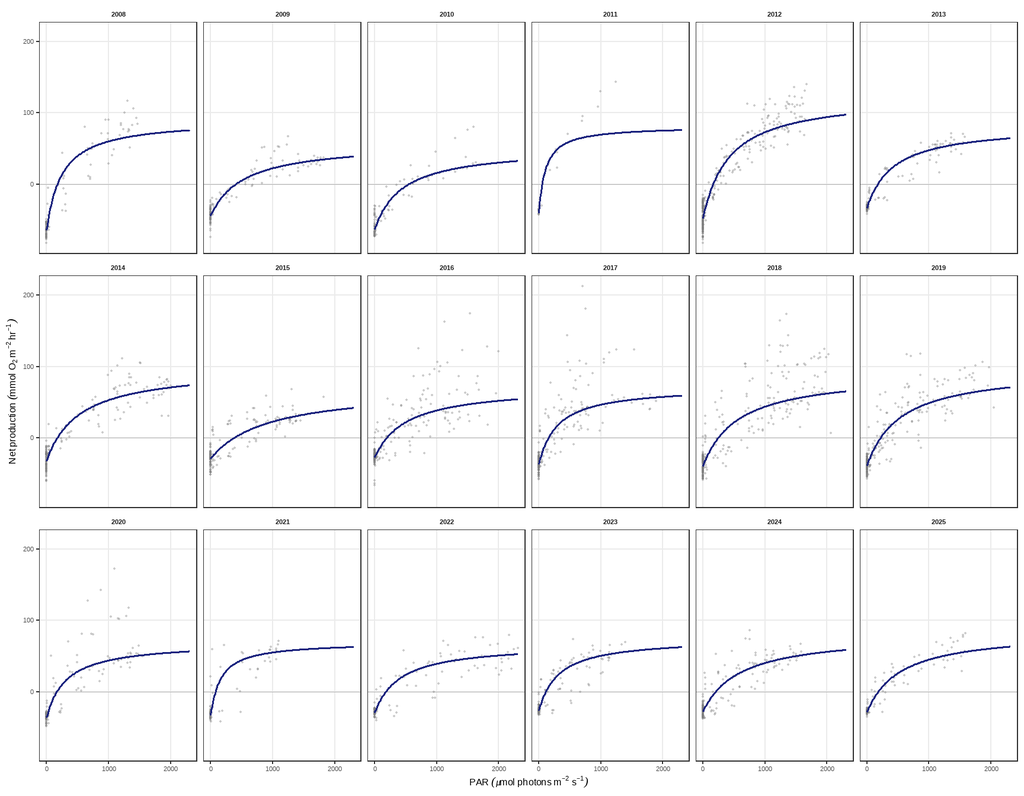

Figure 8: **Figure S1.** Photosynthesis-irradiance (PI) curves by year.

```r
par_seq <- seq(0, max(LTER1_Pnet$PAR, na.rm = TRUE), length.out = 200)

pi_params_plot <- fixef(fit1_f) |>
  as.data.frame() |>
  rownames_to_column("param") |>
  as_tibble() |>
  separate(param, into = c("type", "year_str"), sep = "_Year", remove = FALSE) |>
  mutate(year = as.integer(year_str)) |>
  filter(!is.na(year)) |>
  select(type, year, Estimate) |>
  pivot_wider(names_from = type, values_from = Estimate) |>
  mutate(Rd = -Rd)

fitted_curves <- pi_params_plot |>
  rowwise() |>
  reframe(
    year   = year,
    PAR    = par_seq,
    PP_fit = (alpha * Pmax * par_seq) / (alpha * par_seq + Pmax) - Rd
  )

raw_data_plot <- LTER1_Pnet |>
  mutate(year = as.integer(as.character(Year)))

param_labels <- pi_params_plot |>
  mutate(
    label = sprintf("Pmax = %.0f\nRd = %.0f", Pmax, Rd),
    PAR   = max(LTER1_Pnet$PAR, na.rm = TRUE) * 0.97,
    PP    = min(LTER1_Pnet$PP,  na.rm = TRUE) * 0.85
  )

ggplot() +
  geom_hline(yintercept = 0, colour = "grey70", linewidth = 0.3) +
  geom_point(data = raw_data_plot,
             aes(x = PAR, y = PP),
             colour = "grey50", size = 0.5, alpha = 0.4, shape = 16) +
  geom_line(data = fitted_curves,
            aes(x = PAR, y = PP_fit),
            colour = "#1A237E", linewidth = 0.7) +
  facet_wrap(~year, ncol = 6) +
  scale_x_continuous(breaks = c(0, 1000, 2000)) +
  labs(
    x = expression(PAR~(mu*mol~photons~m^{-2}~s^{-1})),
    y = expression(Net~production~(mmol~O[2]~m^{-2}~hr^{-1}))
  ) +
  theme_bw(base_size = 8) +
  theme(
    strip.background = element_blank(),
    strip.text       = element_text(size = 8, face = "bold"),
    panel.grid.minor = element_blank(),
    axis.text        = element_text(size = 8),
    axis.title = element_text(size = 12))
ggsave(here("Output", "figS1_pi_curves.pdf"), width = 9, height = 7)
```

## Supplementary Figure 2: SEM Observed vs. Fitted Trajectories

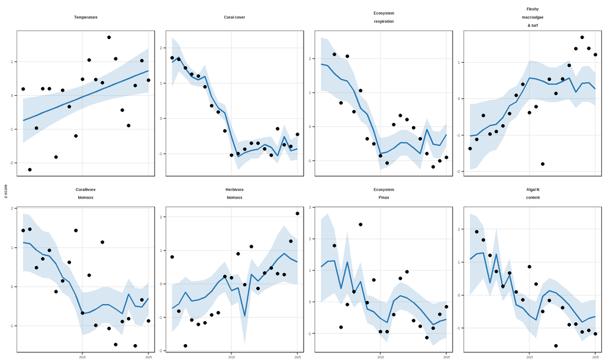

Figure 9: **Figure S2.** SEM observed vs. fitted trajectories.

```r
# Response metadata — ordered by causal depth in the DAG
resp_meta <- tibble(
  resp  = c("temperature", "logcoral", "logrd",  "logfleshy",
            "Corallivore", "herbs",    "logpmax", "Npercent"),
  label = c("Temperature", "Coral cover", "Ecosystem\nrespiration", "Fleshy\nmacroalgae\n& turf",
            "Corallivore\nbiomass", "Herbivore\nbiomass", "Ecosystem\nPmax", "Algal N\ncontent")
)

# Actual calendar years aligned to semdata2 rows
# actual_years must match rows brms used: excludes years where any non-mi()
# predictor is NA (i.e. yearresid = NA when Max_temp = NA for 2025)
actual_years <- Year_Averages |>
  filter(!is.na(log_coral), !is.na(Max_temp)) |>
  pull(Year)

obs_fit_df <- resp_meta$resp |>
  map(function(r) {
    obs  <- semdata2[[r]]
    fit  <- fitted(brms_sem_reduced, resp = r)[, c("Estimate", "Q2.5", "Q97.5")]
    n_fit <- nrow(fit)
    tibble(
      Year     = actual_years[seq_len(n_fit)],
      observed = obs[seq_len(n_fit)],
      fitted   = fit[, "Estimate"],
      lo95     = fit[, "Q2.5"],
      hi95     = fit[, "Q97.5"],
      resp     = r
    )
  }) |>
  bind_rows() |>
  left_join(resp_meta, by = "resp") |>
  mutate(label = factor(label, levels = resp_meta$label))

figS2 <- ggplot(obs_fit_df, aes(x = Year)) +
  geom_ribbon(aes(ymin = lo95, ymax = hi95), fill = "#2c7bb6", alpha = 0.18) +
  geom_line(aes(y = fitted), colour = "#2c7bb6", linewidth = 0.75) +
  geom_point(aes(y = observed), size = 1.6, colour = "black", na.rm = TRUE) +
  facet_wrap(~ label, scales = "free_y", ncol = 4) +
  scale_x_continuous(breaks = c(2005, 2015, 2025), minor_breaks = NULL) +
  labs(x = NULL, y = "z-score") +
  theme_bw(base_size = 10) +
  theme(
    strip.background = element_blank(),
    strip.text       = element_text(size = 9, face = "bold"),
    panel.grid.minor = element_blank(),
    axis.text.x      = element_text(size = 7)
  )

ggsave(here("Output", "figS2_sem_obs_fit.pdf"), plot = figS2, width = 10, height = 6)

figS2
```

## Supplementary Figure 3: SEM Posterior Predictive Checks

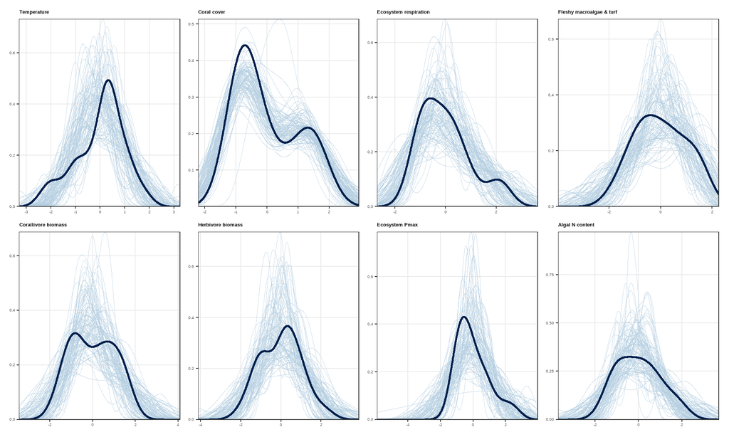

Figure 10: **Figure S3.** Posterior predictive checks.

```r
color_scheme_set("blue")

# resp_meta defined in fig-sem-obs-fit; redefined here for chunk independence
if (!exists("resp_meta")) {
  resp_meta <- tibble(
    resp  = c("temperature", "logcoral", "logrd",  "logfleshy",
              "Corallivore", "herbs",    "logpmax", "Npercent"),
    label = c("Temperature", "Coral cover", "Ecosystem\nrespiration", "Fleshy\nmacroalgae\n& turf",
              "Corallivore\nbiomass", "Herbivore\nbiomass", "Ecosystem\nPmax", "Algal N\ncontent")
  )
}

ppc_plots <- map2(resp_meta$resp, resp_meta$label, function(r, lab) {
  pp_check(brms_sem_reduced, resp = r, ndraws = 100, type = "dens_overlay") +
    ggtitle(gsub("\n", " ", lab)) +
    theme_bw(base_size = 9) +
    theme(
      legend.position  = "none",
      plot.title       = element_text(size = 10, face = "bold"),
      axis.title       = element_text(size = 8),
      panel.grid.minor = element_blank()
    )
})
ggsave(here("Output", "figS3_ppc.pdf"), width = 10, height = 6)
wrap_plots(ppc_plots, ncol = 4)
ggsave(here("Output", "figS3_ppc.pdf"), width = 10, height = 6)
```

## Supplementary Table 1: SEM Path Coefficients

```r
# Build tidy table from brms fixed effects summary
sem_coef_table <- as.data.frame(summary(brms_sem_full)$fixed) |>
  tibble::rownames_to_column("term") |>
  # Keep only regression coefficients (exclude intercepts)
  filter(!grepl("Intercept", term)) |>
  mutate(
    # Parse response and predictor from "response_predictor" format
    Pathway = case_when(
      term == "temperature_Year"         ~ "Year → Temperature",
      term == "logcoral_temperature"     ~ "Temperature → Coral cover",
      term == "logcoral_yearresid"       ~ "Year residual → Coral cover",
      term == "logrd_logcoral"           ~ "Coral cover → Ecosystem respiration",
      term == "logrd_mitemperature"      ~ "Temperature → Ecosystem respiration (direct)",
      term == "logfleshy_logcoral"       ~ "Coral cover → Fleshy macroalgae",
      term == "Corallivore_logcoral"     ~ "Coral cover → Corallivore biomass",
      term == "herbs_logfleshy"          ~ "Fleshy macroalgae → Herbivore biomass",
      term == "logpmax_milogrd"          ~ "Ecosystem respiration → Ecosystem Pmax",
      term == "logpmax_logcoral"         ~ "Coral cover → Ecosystem Pmax (direct)",
      term == "logpmax_mitemperature"    ~ "Temperature → Ecosystem Pmax (direct)",
      term == "Npercent_milogrd"         ~ "Ecosystem respiration → Algal N content",
      TRUE ~ term
    ),
    Credible = if_else(sign(`l-95% CI`) == sign(`u-95% CI`), "†", ""),
    beta  = sprintf("%.3f", Estimate),
    CI    = sprintf("[%.3f, %.3f]", `l-95% CI`, `u-95% CI`),
    Rhat  = sprintf("%.4f", Rhat),
    BESS  = formatC(round(Bulk_ESS), format = "d", big.mark = ","),
    TESS  = formatC(round(Tail_ESS), format = "d", big.mark = ",")
  ) |>
  # Order by causal chain
  mutate(order = case_when(
    grepl("Year →",              Pathway) ~ 1,
    grepl("Temperature →",       Pathway) ~ 2,
    grepl("Year residual →",     Pathway) ~ 2,
    grepl("Coral cover →",       Pathway) ~ 3,
    grepl("Fleshy macroalgae →", Pathway) ~ 4,
    grepl("Ecosystem respiration →", Pathway) ~ 5,
    TRUE ~ 6
  )) |>
  arrange(order, Pathway) |>
  select(Pathway, Credible, beta, CI, Rhat, `Bulk ESS` = BESS, `Tail ESS` = TESS)

kable(sem_coef_table, align = c("l", "c", "r", "c", "r", "r", "r"),
      col.names = c("Pathway", "", "β", "95% CI", "R̂", "Bulk ESS", "Tail ESS")) |>
  kable_styling(bootstrap_options = c("striped", "hover"), full_width = FALSE,
                font_size = 12) |>
  column_spec(1, width = "14em") |>
  column_spec(2, width = "1em") |>
  footnote(symbol = "95% credible interval excludes zero.")
```

[output not shown]

* 95% credible interval excludes zero.

# References

## Climate Data and CMIP6 Models

**Copernicus Climate Data Store**

Copernicus Climate Change Service (C3S) (2023). CMIP6 climate projections. Copernicus Climate Change Service (C3S) Climate Data Store (CDS). https://cds.climate.copernicus.eu/datasets/projections-cmip6. DOI: 10.24381/cds.c866074c

**CMIP6 Overview**

Eyring, V., Bony, S., Meehl, G. A., Senior, C. A., Stevens, B., Stouffer, R. J., & Taylor, K. E. (2016). Overview of the Coupled Model Intercomparison Project Phase 6 (CMIP6) experimental design and organization. *Geoscientific Model Development*, 9(5), 1937–1958. https://doi.org/10.5194/gmd-9-1937-2016

**SSP Scenarios**

O’Neill, B. C., Tebaldi, C., van Vuuren, D. P., Eyring, V., Friedlingstein, P., Hurtt, G., Knutti, R., Kriegler, E., Lamarque, J.-F., Lowe, J., Meehl, G. A., Moss, R., Riahi, K., & Sanderson, B. M. (2016). The Scenario Model Intercomparison Project (ScenarioMIP) for CMIP6. *Geoscientific Model Development*, 9(9), 3461–3482. https://doi.org/10.5194/gmd-9-3461-2016

Riahi, K., van Vuuren, D. P., Kriegler, E., Edmonds, J., O’Neill, B. C., Fujimori, S., Bauer, N., Calvin, K., Dellink, R., Fricko, O., Lutz, W., Popp, A., Cuaresma, J. C., Kc, S., Leimbach, M., Jiang, L., Kram, T., Rao, S., Emmerling, J., … Tavoni, M. (2017). The Shared Socioeconomic Pathways and their energy, land use, and greenhouse gas emissions implications: An overview. *Global Environmental Change*, 42, 153–168. https://doi.org/10.1016/j.gloenvch.2016.05.009

**Individual CMIP6 Models**

Bi, D., Dix, M., Marsland, S., O’Farrell, S., Sullivan, A., Bodman, R., Law, R., Harman, I., Srbinovsky, J., Rashid, H. A., Dobrohotoff, P., Mackallah, C., Yan, H., Hirst, A., Savita, A., Dias, F. B., Woodhouse, M., Fiedler, R., & Heerdegen, A. (2020). Configuration and spin-up of ACCESS-CM2, the new generation Australian Community Climate and Earth System Simulator Coupled Model. *Journal of Southern Hemisphere Earth Systems Science*, 70(1), 225–251. https://doi.org/10.1071/ES19040

Boucher, O., Servonnat, J., Albright, A. L., Aumont, O., Balkanski, Y., Bastrikov, V., Bekki, S., Bonnet, R., Bony, S., Bopp, L., Braconnot, P., Brockmann, P., Cadule, P., Caubel, A., Cheruy, F., Codron, F., Cozic, A., Cugnet, D., D’Andrea, F., … Vuichard, N. (2020). Presentation and evaluation of the IPSL‐CM6A‐LR climate model. *Journal of Advances in Modeling Earth Systems*, 12(7), e2019MS002010. https://doi.org/10.1029/2019MS002010

Döscher, R., Acosta, M., Alessandri, A., Anthoni, P., Arsouze, T., Bergman, T., Bernardello, R., Boussetta, S., Caron, L.-P., Carver, G., Castrillo, M., Catalano, F., Cvijanovic, I., Davini, P., Dekker, E., Doblas-Reyes, F. J., Docquier, D., Echevarria, P., Fladrich, U., … Zhang, Q. (2022). The EC-Earth3 Earth system model for the Coupled Model Intercomparison Project 6. *Geoscientific Model Development*, 15(7), 2973–3020. https://doi.org/10.5194/gmd-15-2973-2022

Dunne, J. P., Horowitz, L. W., Adcroft, A. J., Ginoux, P., Held, I. M., John, J. G., Krasting, J. P., Malyshev, S., Naik, V., Paulot, F., Shevliakova, E., Stock, C. A., Zadeh, N., Balaji, V., Blanton, C., Dunne, K. A., Dupuis, C., Durachta, J., Dussin, R., … Zhao, M. (2020). The GFDL Earth System Model version 4.1 (GFDL‐ESM 4.1): Overall coupled model description and simulation characteristics. *Journal of Advances in Modeling Earth Systems*, 12(11), e2019MS002015. https://doi.org/10.1029/2019MS002015

Müller, W. A., Jungclaus, J. H., Mauritsen, T., Baehr, J., Bittner, M., Budich, R., Bunzel, F., Esch, M., Ghosh, R., Haak, H., Ilyina, T., Kleine, T., Kornblueh, L., Li, H., Modali, K., Notz, D., Pohlmann, H., Segschneider, J., Tian, F., … Marotzke, J. (2018). A higher-resolution version of the Max Planck Institute Earth System Model (MPI‐ESM1.2‐HR). *Journal of Advances in Modeling Earth Systems*, 10(7), 1383–1413. https://doi.org/10.1029/2017MS001217

Seland, Ø., Bentsen, M., Olivié, D., Toniazzo, T., Gjermundsen, A., Graff, L. S., Debernard, J. B., Gupta, A. K., He, Y.-C., Kirkevåg, A., Schwinger, J., Tjiputra, J., Aas, K. S., Bethke, I., Fan, Y., Griesfeller, J., Grini, A., Guo, C., Ilicak, M., … Schulz, M. (2020). Overview of the Norwegian Earth System Model (NorESM2) and key climate response of CMIP6 DECK and historical simulations. *Geoscientific Model Development*, 13(12), 6165–6200. https://doi.org/10.5194/gmd-13-6165-2020

Sellar, A. A., Jones, C. G., Mulcahy, J. P., Tang, Y., Yool, A., Wiltshire, A., O’Connor, F. M., Stringer, M., Hill, R., Palmieri, J., Woodward, S., de Mora, L., Kuhlbrodt, T., Rumbold, S. T., Kelley, D. I., Ellis, R., Johnson, C. E., Walton, J., Abraham, N. L., … Zerroukat, M. (2019). UKESM1: Description and evaluation of the UK Earth System Model. *Journal of Advances in Modeling Earth Systems*, 11(12), 4513–4558. https://doi.org/10.1029/2019MS001739

Tatebe, H., Ogura, T., Nitta, T., Komuro, Y., Ogochi, K., Takemura, T., Sudo, K., Sekiguchi, M., Abe, M., Saito, F., Chikira, M., Watanabe, S., Mori, M., Hirota, N., Kawatani, Y., Mochizuki, T., Yoshimura, K., Takata, K., O’ishi, R., … Kimoto, M. (2019). Description and basic evaluation of simulated mean state, internal variability, and climate sensitivity in MIROC6. *Geoscientific Model Development*, 12(7), 2727–2765. https://doi.org/10.5194/gmd-12-2727-2019

Wu, T., Lu, Y., Fang, Y., Xin, X., Li, L., Li, W., Jie, W., Zhang, J., Liu, Y., Zhang, L., Zhang, F., Zhang, Y., Wu, F., Li, J., Chu, M., Wang, Z., Shi, X., Liu, X., Wei, M., … Zhou, W. (2019). The Beijing Climate Center Climate System Model (BCC‐CSM2): Main progress from CMIP5 to CMIP6. *Geoscientific Model Development*, 12(4), 1573–1600. https://doi.org/10.5194/gmd-12-1573-2019

Yukimoto, S., Kawai, H., Koshiro, T., Oshima, N., Yoshida, K., Urakawa, S., Tsujino, H., Deushi, M., Tanaka, T., Hosaka, M., Yabu, S., Yoshimura, H., Shindo, E., Mizuta, R., Obata, A., Adachi, Y., & Ishii, M. (2019). The Meteorological Research Institute Earth System Model version 2.0, MRI‐ESM2.0: Description and basic evaluation of the physical component. *Journal of the Meteorological Society of Japan*, 97(5), 931–965. https://doi.org/10.2151/jmsj.2019-051

## Statistical Methods and Software

Bürkner, P.-C. (2017). brms: An R package for Bayesian multilevel models using Stan. *Journal of Statistical Software*, 80(1), 1–28. https://doi.org/10.18637/jss.v080.i01

Bürkner, P.-C. (2018). Advanced Bayesian multilevel modeling with the R package brms. *The R Journal*, 10(1), 395–411. https://doi.org/10.32614/RJ-2018-017

Carpenter, B., Gelman, A., Hoffman, M. D., Lee, D., Goodrich, B., Betancourt, M., Brubaker, M., Guo, J., Li, P., & Riddell, A. (2017). Stan: A probabilistic programming language. *Journal of Statistical Software*, 76(1), 1–32. https://doi.org/10.18637/jss.v076.i01

Csárdi, G., & Nepusz, T. (2006). The igraph software package for complex network research. *InterJournal, Complex Systems*, 1695. https://igraph.org

Gelman, A., Goodrich, B., Gabry, J., & Vehtari, A. (2019). R-squared for Bayesian regression models. *The American Statistician*, 73(3), 307–309. https://doi.org/10.1080/00031305.2018.1549100

Hufkens, K., Stauffer, R., & Campitelli, E. (2019). ecmwfr: Programmatic interface to the two main European Centre for Medium-Range Weather Forecasts APIs. *Journal of Open Source Software*, 4(43), 1867. https://doi.org/10.21105/joss.01867

Kay, M. (2023). tidybayes: Tidy data and ‘Geoms’ for Bayesian models. R package version 3.0.6. https://mjskay.github.io/tidybayes/

Pedersen, T. L. (2024). patchwork: The composer of plots. R package version 1.2.0. https://patchwork.data-imaginist.com

Pierce, D. (2024). ncdf4: Interface to Unidata netCDF (Version 4 or Earlier) Format Data Files. R package version 1.22. https://CRAN.R-project.org/package=ncdf4

Wickham, H., Averick, M., Bryan, J., Chang, W., McGowan, L. D., François, R., Grolemund, G., Hayes, A., Henry, L., Hester, J., Kuhn, M., Pedersen, T. L., Miller, E., Bache, S. M., Müller, K., Ooms, J., Robinson, D., Seidel, D. P., Spinu, V., … Yutani, H. (2019). Welcome to the tidyverse. *Journal of Open Source Software*, 4(43), 1686. https://doi.org/10.21105/joss.01686

Wilke, C. O. (2024). cowplot: Streamlined Plot Theme and Plot Annotations for ‘ggplot2’. R package version 1.1.3. https://wilkelab.org/cowplot/

Zeileis, A., & Grothendieck, G. (2005). zoo: S3 infrastructure for regular and irregular time series. *Journal of Statistical Software*, 14(6), 1–27. https://doi.org/10.18637/jss.v014.i06

## Software and Reproducibility

Key packages: **tidyverse** 2.0 (Wickham et al. 2019), **brms** 2.21 (Bürkner 2017), **tidybayes** 3.0 (Kay 2023), **patchwork** 1.2 (Pedersen 2024), **ggraph** 2.1 and **igraph** 1.6 (Csárdi & Nepusz 2006), **httr2** (Wickham 2023), **zoo** (Zeileis & Grothendieck 2005), **cowplot** (Wilke 2024), **ecmwfr** (Hufkens et al. 2019; https://bluegreen-labs.github.io/ecmwfr/), **ncdf4** (Pierce 2024). Stan 2.32 served as the computational backend. CMIP6 SST data were accessed from the Copernicus Climate Data Store (https://cds.climate.copernicus.eu/datasets/projections-cmip6; DOI: 10.24381/cds.c866074c). MCR LTER raw data are publicly archived through the EDI Data Portal (https://edirepository.org).